# EDA practice (FIFA)

In this example we will do some *Exploratory Data Analysis* (EDA) using data on players from the 2010 World Cup

The data frame contains 595 observations on the following variables:

| Variable | Description |
| --- | --- |
| `Player` | Player’s last name |
| `Team` | Country |
| `Position` | a factor (levels: `Defender`, `Forward`, `Goalkeeper`, `Midfielder`) |
| `Time` | Time played in minutes |
| `Shots` | Number of shots attempted |
| `Passes` | Number of passes made |
| `Tackles` | Number of tackles made |
| `Saves` | Number of saves made |

1. Load the `tidyverse` package

```r
library(tidyverse)
```

2. Get the data:

```r
fifa_link <- "https://raw.githubusercontent.com/reisanar/datasets/master/worldcup.csv"
fifa10 <- read_csv(fifa_link)
```

3. Learn about the nature of the data

```r
glimpse(fifa10)
```

```
Rows: 595
Columns: 8
$ Player   <chr> "Abdoun", "Abe", "Abidal", "Abou Diaby", "Aboubakar", "Abreu", "Addy", "Adiyiah", "Afellay", "Afolabi", "Agger", "Aguilar", "Aguero", "Ahn Young-Hak", "Alcaraz"~
$ Team     <chr> "Algeria", "Japan", "France", "France", "Cameroon", "Uruguay", "Ghana", "Ghana", "Netherlands", "Nigeria", "Denmark", "Mexico", "Argentina", "North Korea", "Par~
$ Position <chr> "Midfielder", "Midfielder", "Defender", "Midfielder", "Forward", "Forward", "Defender", "Forward", "Midfielder", "Defender", "Defender", "Defender", "Forward", ~
$ Time     <dbl> 16, 351, 180, 270, 46, 72, 138, 33, 21, 103, 270, 55, 106, 270, 390, 90, 136, 506, 82, 180, 11, 5, 117, 510, 105, 13, 570, 480, 360, 270, 270, 389, 90, 167, 82,~
$ Shots    <dbl> 0, 0, 0, 1, 2, 0, 0, 0, 5, 0, 2, 0, 2, 1, 1, 1, 5, 9, 0, 1, 0, 1, 7, 4, 1, 0, 5, 11, 0, 0, 1, 3, 0, 0, 0, 3, 4, 2, 6, 0, 0, 2, 0, 0, 0, 0, 2, 0, 0, 1, 0, 4, 2, ~
$ Passes   <dbl> 6, 101, 91, 111, 16, 15, 51, 9, 22, 38, 120, 31, 57, 123, 172, 59, 42, 465, 31, 57, 4, 7, 37, 307, 54, 12, 195, 214, 142, 116, 70, 170, 44, 84, 42, 104, 59, 38,~
$ Tackles  <dbl> 0, 14, 6, 5, 0, 0, 2, 0, 0, 1, 10, 2, 2, 11, 13, 7, 3, 18, 0, 1, 1, 0, 1, 11, 2, 0, 21, 9, 12, 5, 8, 15, 1, 6, 1, 5, 2, 3, 2, 0, 0, 8, 3, 3, 0, 2, 7, 0, 1, 8, 0~
$ Saves    <dbl> 0, 0, 0, 0, 0, 0, 0, 0, 0, 0, 0, 0, 0, 0, 0, 0, 0, 0, 0, 0, 0, 0, 0, 0, 0, 0, 0, 0, 0, 0, 0, 0, 0, 0, 0, 0, 0, 0, 0, 0, 8, 0, 0, 0, 0, 0, 0, 0, 0, 0, 11, 0, 0, ~
```

**Challenge**

- Use the `filter()` function to find the names of at least 3 players from Spain’s national team during the 2010 world cup.

```r
fifa10 %>%
  filter(Team == "Spain")
```

| Player | Team | Position | Time | Shots | Passes | Tackles | Saves |
| --- | --- | --- | --- | --- | --- | --- | --- |
| Alonso | Spain | Midfielder | 506 | 9 | 465 | 18 | 0 |
| Arbeloa | Spain | Defender | 13 | 0 | 12 | 0 | 0 |
| Busquets | Spain | Midfielder | 511 | 0 | 466 | 15 | 0 |
| Capdevila | Spain | Defender | 540 | 1 | 310 | 10 | 0 |
| Casillas | Spain | Goalkeeper | 540 | 0 | 67 | 0 | 11 |
| Fabregas | Spain | Midfielder | 94 | 1 | 116 | 2 | 0 |
| Iniesta | Spain | Midfielder | 437 | 8 | 299 | 11 | 0 |
| Javi Martinez | Spain | Midfielder | 17 | 0 | 17 | 0 | 0 |
| Jesus Navas | Spain | Midfielder | 118 | 4 | 61 | 1 | 0 |
| Juan Mata | Spain | Midfielder | 20 | 1 | 16 | 0 | 0 |

[output cut: 10 more lines]

## Boxplot

4. We can create a boxplot that shows the relationship between the number of `Passes` by a player (vertical axis) based on his `Position` in the field (horizontal axis).

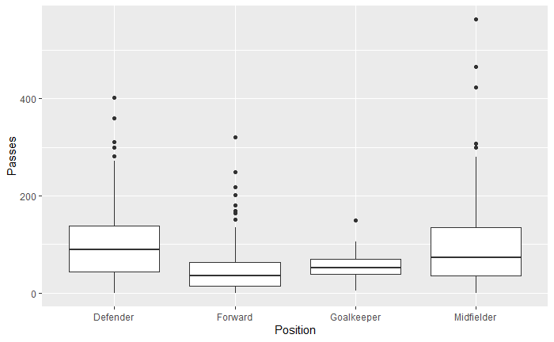

```r
ggplot(data = fifa10) +
  geom_boxplot(aes(x = Position, y = Passes))
```

**Challenge**

- What do you notice from the above boxplots?
- Can you create a boxplot that shows the relationship between the number of `Shots` by a player (vertical axis) based on his `Position` in the field (horizontal axis).

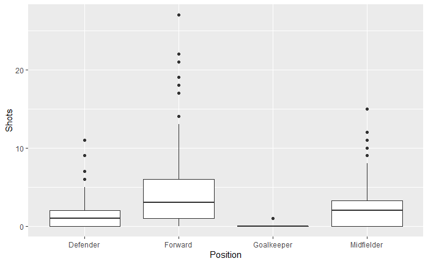

```r
ggplot(data = fifa10) +
  geom_boxplot(aes(x = Position, y = Shots))
```

- What do you notice?

Wgat about the GK?:

```r
fifa10 %>%
  filter(Position == "Goalkeeper", Shots > 0)
```

| Player | Team | Position | Time | Shots | Passes | Tackles | Saves |
| --- | --- | --- | --- | --- | --- | --- | --- |
| Khune | South Africa | Goalkeeper | 166 | 1 | 24 | 0 | 4 |

## Scatterplot

5. To understand the relationship between the number of passes and the number of tackles, let us use a *scatter plot* with `Tackles` in the horizontal axis, and `Passes` in the vertical axis. Color the points by `Position`

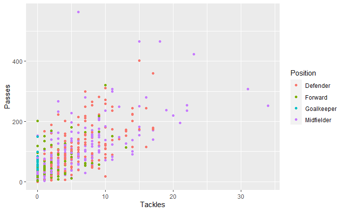

```r
ggplot(data = fifa10)+
  geom_point(aes(x = Tackles, y = Passes, color = Position))
```

**Challenge**

- Do you notice anything in particular about those players in `Goalkeeper` and `Forward` positions?

```r
fifa10 %>%
  filter(Passes > 400, Position == "Midfielder")
```

| Player | Team | Position | Time | Shots | Passes | Tackles | Saves |
| --- | --- | --- | --- | --- | --- | --- | --- |
| Alonso | Spain | Midfielder | 506 | 9 | 465 | 18 | 0 |
| Busquets | Spain | Midfielder | 511 | 0 | 466 | 15 | 0 |
| Schweinsteiger | Germany | Midfielder | 531 | 5 | 423 | 23 | 0 |
| Xavi | Spain | Midfielder | 515 | 4 | 563 | 6 | 0 |

6. We can also check the relationship between the number of minutes played in the tournament (in the horizontal axis) and the number of passes completed by the player (in the vertical axis). Color the points by `Position`

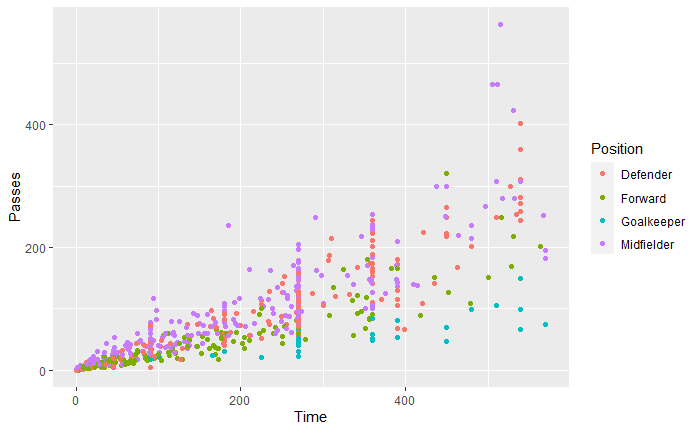

```r
ggplot(data = fifa10) +
  geom_point(aes(x = Time, y = Passes, color = Position))
```

**Challenge**

- Do you notice any particular *structure/pattern* in the graph above?

Accumulation of points in certain values of time, probably explained by teams making progress towards the final stages of the tournament.

7. We can even add the variable `Shots` to the previous plot and plot the points based on the number of shots per player. Use the option `size=Shots` in the aesthetics.

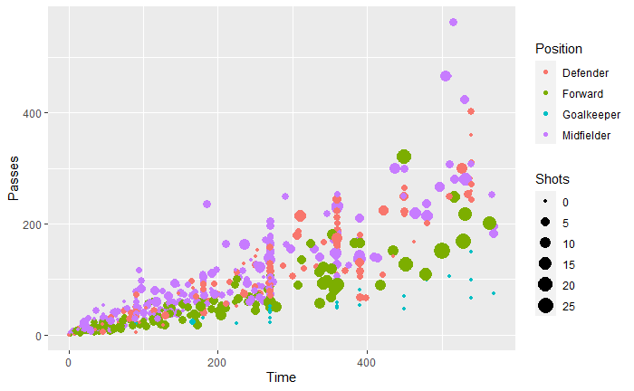

```r
ggplot(data = fifa10) +
  geom_point(aes(x = Time, y = Passes, color = Position, size = Shots))
```

**Challenge**

- Can you find the name of any *outstanding* players based on the graph above?

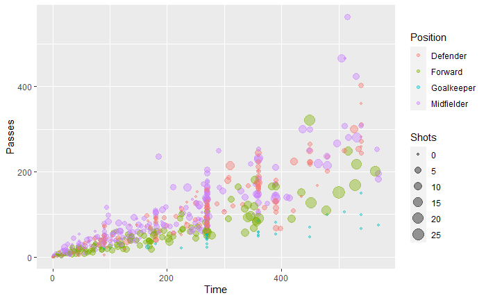

```r
ggplot(data = fifa10) +
  geom_point(aes(x = Time, y = Passes,
                 color = Position, size = Shots),
             alpha = 0.4)
```

Who was the player that had more than 500 passes?

```r
fifa10 %>%
  filter(Passes > 500)
```

| Player | Team | Position | Time | Shots | Passes | Tackles | Saves |
| --- | --- | --- | --- | --- | --- | --- | --- |
| Xavi | Spain | Midfielder | 515 | 4 | 563 | 6 | 0 |